# Project: Investigate a Dataset - [No Show Appointments]

- Introduction
- Data Wrangling
- Exploratory Data Analysis
- Conclusions

## Introduction

### Dataset Description

> Threre are 110.527 medical appointments its 14 associated variables (characteristics). The most important one if the patient show-up or no-show to the appointmen!

### Questions for Analysis

> in order to find what factors are most important to predict weather the patient will show up on time or not i asked myself these questions:
> 1. Does the difference between Appointment date and Actual date effect on showing or not to the appointment?
> 2. Does people with a diesease tend to show up more than other?
> 3. Does receiving a message increases the numbenr of showings?

```python
import pandas as pd
import numpy as np
import seaborn as sns
%matplotlib inline
from sklearn import datasets
import seaborn as sns
import matplotlib.pyplot as plt
from datetime import date
from string import ascii_letters
import matplotlib.pyplot as plt
from statsmodels.robust.scale import mad
```

## Data Wrangling

### General Properties

```python
# Load your data and print out a few lines.
dataset_df=pd.read_csv('no-show-appointments.csv')
```

```python
# Function to show the data frame information
def information():
    dataset_df.head()
information()
```

Columns Description:

```python
#To know the attrubite names and the types of each one of them.
dataset_df.dtypes
```

```
PatientId         float64
AppointmentID       int64
Gender             object
ScheduledDay       object
AppointmentDay     object
Age                 int64
Neighbourhood      object
Scholarship         int64
Hipertension        int64
Diabetes            int64
Alcoholism          int64
Handcap             int64
SMS_received        int64
No-show            object
dtype: object
```

As we can see we have 5 Object attributes, 8 Int attributes, 1 Float attribute.

```python
#To know the sum of the null
dataset_df.isnull().sum()
```

```
PatientId         0
AppointmentID     0
Gender            0
ScheduledDay      0
AppointmentDay    0
Age               0
Neighbourhood     0
Scholarship       0
Hipertension      0
Diabetes          0
Alcoholism        0
Handcap           0
SMS_received      0
No-show           0
dtype: int64
```

We do not have any null values

```python
dataset_df.describe()
```

|  | PatientId | AppointmentID | Age | Scholarship | Hipertension | Diabetes | Alcoholism | Handcap | SMS_received |
| --- | --- | --- | --- | --- | --- | --- | --- | --- | --- |
| count | 1.105270e+05 | 1.105270e+05 | 110527.000000 | 110527.000000 | 110527.000000 | 110527.000000 | 110527.000000 | 110527.000000 | 110527.000000 |
| mean | 1.474963e+14 | 5.675305e+06 | 37.088874 | 0.098266 | 0.197246 | 0.071865 | 0.030400 | 0.022248 | 0.321026 |
| std | 2.560949e+14 | 7.129575e+04 | 23.110205 | 0.297675 | 0.397921 | 0.258265 | 0.171686 | 0.161543 | 0.466873 |
| min | 3.921784e+04 | 5.030230e+06 | -1.000000 | 0.000000 | 0.000000 | 0.000000 | 0.000000 | 0.000000 | 0.000000 |
| 25% | 4.172614e+12 | 5.640286e+06 | 18.000000 | 0.000000 | 0.000000 | 0.000000 | 0.000000 | 0.000000 | 0.000000 |
| 50% | 3.173184e+13 | 5.680573e+06 | 37.000000 | 0.000000 | 0.000000 | 0.000000 | 0.000000 | 0.000000 | 0.000000 |
| 75% | 9.439172e+13 | 5.725524e+06 | 55.000000 | 0.000000 | 0.000000 | 0.000000 | 0.000000 | 0.000000 | 1.000000 |
| max | 9.999816e+14 | 5.790484e+06 | 115.000000 | 1.000000 | 1.000000 | 1.000000 | 1.000000 | 4.000000 | 1.000000 |

## Data Cleaning

```python
#Dates are assigned as objects and we need them to be assigned as dates inorder to calculate
#the difference between the scheduled and actual date
dataset_df["ScheduledDay"]= pd.to_datetime(dataset_df["ScheduledDay"], errors='coerce')
dataset_df["AppointmentDay"]= pd.to_datetime(dataset_df["AppointmentDay"], errors='coerce')
```

```python
#Calculating the difference days between scheduled and actual date
dataset_df['diff_days'] =dataset_df['AppointmentDay'] - dataset_df['ScheduledDay']
dataset_df['diff_days'] =dataset_df['diff_days']/np.timedelta64(1,'D')
dataset_df = dataset_df.drop(dataset_df[dataset_df['diff_days'] < 0].index)
```

```python
#Binning the difference days to make it easier to plot and understand
dataset_df=dataset_df.assign(diff_category=pd.cut(dataset_df.diff_days,[0,1,7,14,21,28,35],
labels=['Same day ',' Week ',' Two weeks   ',' Three weeks ',' Month    ',' More than a month '],include_lowest=True))
```

```python
#Bin ages in order to plot them easily
dataset_df['Age_category'] = pd.cut(x=dataset_df['Age'],
bins=[0,10,20,30,40,50,60,70,80,90,100],labels=['0-10 ', '10-20','20-30','30-40',' 40-50','50-60','60-70','70-80','80-90','90-100'])
```

```python
#To prevent having NaN values in the ages after binning we will drop
#any outliers
dataset_df = dataset_df.dropna()
```

```python
dataset_df['Total-disease'] = dataset_df['Hipertension'] + dataset_df['Diabetes'] + dataset_df['Alcoholism']+ dataset_df['Handcap']
```

```python
dataset_df.round(0)
```

|  | PatientId | AppointmentID | Gender | ScheduledDay | AppointmentDay | Age | Neighbourhood | Scholarship | Hipertension | Diabetes | Alcoholism | Handcap | SMS_received | No-show | diff_days | diff_category | Age_category | Total-disease |
| --- | --- | --- | --- | --- | --- | --- | --- | --- | --- | --- | --- | --- | --- | --- | --- | --- | --- | --- |
| 5 | 9.598513e+13 | 5626772 | F | 2016-04-27 08:36:51+00:00 | 2016-04-29 00:00:00+00:00 | 76 | REPÚBLICA | 0 | 1 | 0 | 0 | 0 | 0 | No | 2.0 | Week | 70-80 | 1 |
| 6 | 7.336882e+14 | 5630279 | F | 2016-04-27 15:05:12+00:00 | 2016-04-29 00:00:00+00:00 | 23 | GOIABEIRAS | 0 | 0 | 0 | 0 | 0 | 0 | Yes | 1.0 | Week | 20-30 | 0 |
| 7 | 3.449833e+12 | 5630575 | F | 2016-04-27 15:39:58+00:00 | 2016-04-29 00:00:00+00:00 | 39 | GOIABEIRAS | 0 | 0 | 0 | 0 | 0 | 0 | Yes | 1.0 | Week | 30-40 | 0 |
| 9 | 7.812456e+13 | 5629123 | F | 2016-04-27 12:48:25+00:00 | 2016-04-29 00:00:00+00:00 | 19 | CONQUISTA | 0 | 0 | 0 | 0 | 0 | 0 | No | 1.0 | Week | 10-20 | 0 |
| 10 | 7.345362e+14 | 5630213 | F | 2016-04-27 14:58:11+00:00 | 2016-04-29 00:00:00+00:00 | 30 | NOVA PALESTINA | 0 | 0 | 0 | 0 | 0 | 0 | No | 1.0 | Week | 20-30 | 0 |
| ... | ... | ... | ... | ... | ... | ... | ... | ... | ... | ... | ... | ... | ... | ... | ... | ... | ... | ... |
| 110516 | 6.923772e+13 | 5780205 | F | 2016-06-07 07:45:16+00:00 | 2016-06-08 00:00:00+00:00 | 37 | MARIA ORTIZ | 0 | 0 | 0 | 0 | 0 | 0 | Yes | 1.0 | Same day | 30-40 | 0 |
| 110520 | 9.969977e+14 | 5650534 | F | 2016-05-03 07:51:47+00:00 | 2016-06-07 00:00:00+00:00 | 42 | MARIA ORTIZ | 0 | 0 | 0 | 0 | 0 | 1 | No | 35.0 | More than a month | 40-50 | 0 |
| 110521 | 3.635534e+13 | 5651072 | F | 2016-05-03 08:23:40+00:00 | 2016-06-07 00:00:00+00:00 | 53 | MARIA ORTIZ | 0 | 0 | 0 | 0 | 0 | 1 | No | 35.0 | More than a month | 50-60 | 0 |
| 110522 | 2.572134e+12 | 5651768 | F | 2016-05-03 09:15:35+00:00 | 2016-06-07 00:00:00+00:00 | 56 | MARIA ORTIZ | 0 | 0 | 0 | 0 | 0 | 1 | No | 35.0 | More than a month | 50-60 | 0 |
| 110523 | 3.596266e+12 | 5650093 | F | 2016-05-03 07:27:33+00:00 | 2016-06-07 00:00:00+00:00 | 51 | MARIA ORTIZ | 0 | 0 | 0 | 0 | 0 | 1 | No | 35.0 | More than a month | 50-60 | 0 |

63335 rows × 18 columns

## Exploratory Data Analysis

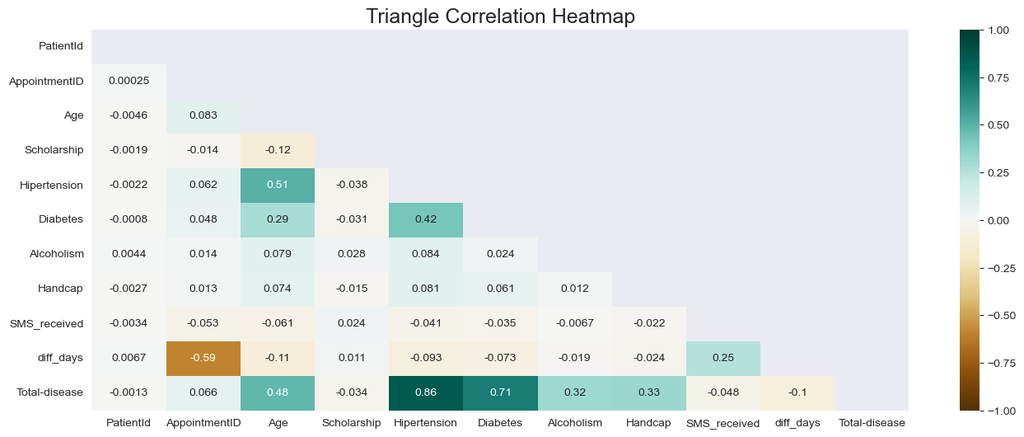

```python
plt.figure(figsize=(16, 6))
# define the mask to set the values in the upper triangle to True
mask = np.triu(np.ones_like(dataset_df.corr(), dtype=np.bool))
heatmap = sns.heatmap(dataset_df.corr(), mask=mask, vmin=-1, vmax=1, annot=True, cmap='BrBG')
heatmap.set_title('Triangle Correlation Heatmap', fontdict={'fontsize':18});
```

From the heat map above we can see that **Age** and **Total diseases** are correlated. We also can see that **Difference days** and **SMS-receive** are also correlated.

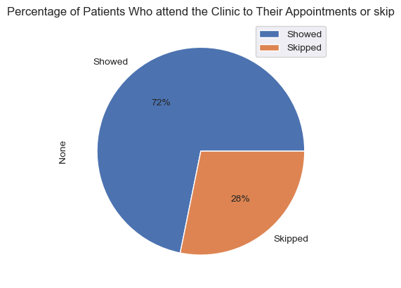

```python
dataset_df['No-show'] = dataset_df['No-show'].map({'Yes': 'Skipped', 'No': 'Showed'})
dataset_df.groupby('No-show').size().plot(kind='pie', legend=True, autopct='%1.0f%%')
plt.title('Percentage of Patients Who attend the Clinic to Their Appointments or skip')
```

Figure 1: We can see from the graph that 28% of patients skip their appointments.

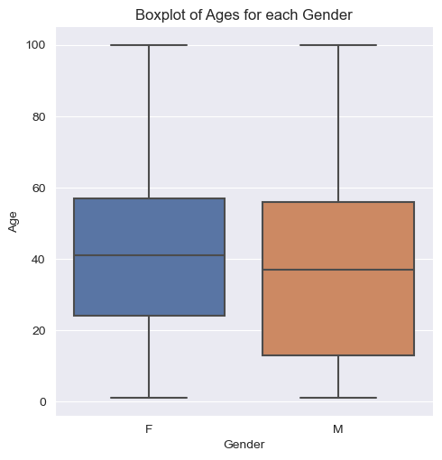

```python
sns.catplot(x="Gender", y="Age",data=dataset_df, kind="box");
plt.title('Boxplot of Ages for each Gender')
```

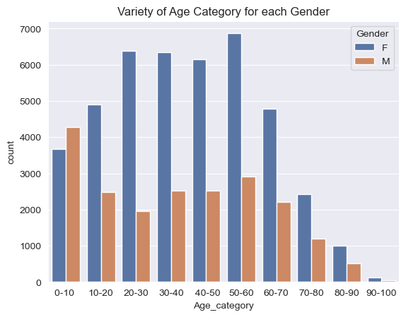

```python
sns.set_style("darkgrid")
sns.set_palette("deep")
sns.countplot(x='Age_category',hue='Gender',data=dataset_df)
plt.title('Variety of Age Category for each Gender')
```

Figure 3: from the bar graph above we can clearly see that most patients are women and th from the most frequent ages are from 20-60. For men most of the patience are from the age 0 - 10.

### Research Question 1:

Does the difference between Appointment date and Actual date effect on showing or not to the appointment?)

[figure not shown]

```python
dataset_df.groupby(['diff_category', 'No-show']).size().unstack().plot(kind='bar', stacked=True)
plt.title('Number of Patients Who Showed or Skipped Based on Days Difference')
```

Figure 4: from the graph we can see that having the appointment on the same day has the least amount of skipping. . And we kind of notice that the longer the period is the more skippings we have. Plus, most of the dates are not on the same scheduled day but within the same week.

### Research Question 2

Does people with a diesease tend to show up more than the others?

[figure not shown]

```python
dataset_df.groupby(['Total-disease', 'No-show']).size().unstack().plot(kind='bar', stacked=True)
plt.title('Number of Patients Who Showed or Skipped Based on Days Difference')
```

Figure 5: from the graph above we can conclude that the increasing on total disease causes a decreasing on the number of skippings.

### Research Question 3

Does receiving a message increases the numbenr of showings?

```python
dataset_df["No-show"]=dataset_df["No-show"].replace(to_replace=['Showed','Skipped'],value=[1,0])
```

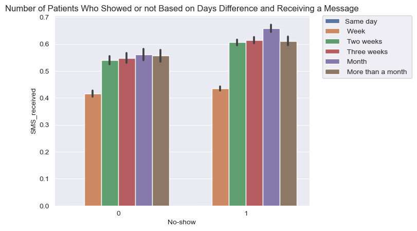

```python
sns.barplot(data=dataset_df, x='No-show', y='SMS_received', hue='diff_category')
plt.legend(bbox_to_anchor=(1.05, 1), loc= 'upper left', borderaxespad=0)
plt.title('Number of Patients Who Showed or not Based on Days Difference and Receiving a Message')
```

Figure 6: from the graph above we can notice that receiving a message can clearly increase the number of showings especially for periods that are longer than two weeks. We can notice also that people with the an appointment at the same scheduled day do not receive any messages.

## Conclusions

After all the changing some data formats, binning on some columns, doing all needed calculations and analyzing all the plots we can conclude the following:

#### Results:

`1.` The difference between the scheduled and actual date can increase the number of skipping. The longer period it is the more skipping there would be.

`2.` People with diesease tend to Show up more than others. And the more total disease the patience has the less skipping there is.

`3.`Receiving a message can decrease the number of skipping. Espically, for longer periods between the scheduled and actual date

#### Limitation:

`1.` Choosing the right graph type with the right columns.

`2.` Choosing the appropriate titles for The plots.

`3.` Calculating the difference between scheduled and actual appointment day.